# STAT540 - Project 2

Stephanie Yu

2024-05-09

```r
# load the packages for graphing and data wrangling
library(ggplot2)
library(dplyr)
```

**Note:** If you `Rmd` file submission knits you will receive total of **(10 points)**.

For the data wrangling use function from the `dplyr` package

# Project Objectives?

Leading up to the 2016 presidential election, many pollsters predicted that the Democratic candidate, Hillary Clinton, would win a “decisive victory.”. However, as we all know, the election was won by the Republican candidate, and current president, Donald Trump. In general biases, not accounted for by prediction models, often affect many pollsters. In this project, you are going to further investigate these biases through comparisons across both national and state-level races.

The project requires an **.RData** file, `election_polls.RData`, containing a `data.frame` (`polls`) with several years worth of polling data (2008, 2010, 2012, 2014 and 2016). The polls cover federal elections for house representatives, senators and the president, and includes polling data from up to a year before the election date.

```r
library(tidyverse)
load("elections_polls.RData")
str(polls)
```

```
## 'data.frame':    6847 obs. of  16 variables:
##  $ race             : chr  "2016_Pres_NM" "2016_Pres_VA" "2016_Pres_IA" "2016_Pres_WI" ...
##  $ race_state       : chr  "2016_Pres_NM" "2016_Pres_VA" "2016_Pres_IA" "2016_Pres_WI" ...
##  $ state            : chr  "NM" "VA" "IA" "WI" ...
##  $ state_long       : chr  "new mexico" "virginia" "iowa" "wisconsin" ...
##  $ type             : chr  "Pres" "Pres" "Pres" "Pres" ...
##  $ year             : num  2016 2016 2016 2016 2016 ...
##  $ pollster         : Factor w/ 636 levels "ABC News/Washington Post",..: 195 130 148 95 149 87 132 132 1 65 ...
##  $ samplesize       : num  8439 1238 800 1255 800 ...
##  $ startdate        : Date, format: "2016-11-06" "2016-11-03" ...
##  $ enddate          : Date, format: "2016-11-06" "2016-11-04" ...
##  $ democrat_name    : chr  "clinton" "clinton" "clinton" "clinton" ...
##  $ democrat_poll    : num  46 48 39 46 44 46 46 47 48 44 ...
##  $ democrat_result  : num  48.3 49.8 41.7 46.5 46.2 45.9 47.8 46.2 49.8 45.9 ...
##  $ republican_name  : chr  "trump" "trump" "trump" "trump" ...
##  $ republican_poll  : num  44 43 46 40 44 49 45 45 42 48 ...
##  $ republican_result: num  40 44.4 51.1 47.2 49.8 51 49 49.8 44.4 51 ...
```

The `polls` `data.frame` contains the following columns:

- `race`: race identifier year_electiontype_location.
- `race_state`: race identifier year_electiontype_state. In contrast to the previous column, this identifier ignores information about counties and only contains information at the state level.
- `state`: abbreviation of state of the election
- `state_long`: full name of the state
- `type`: type of race. Could be either presidential (Pres), senatorial election (Sen-G) or house representative election (House-G).
- `year`: election year
- `pollster`: name of the pollster
- `samplesize`: size of the sample used in the poll
- `startdate`: start date of the pole. If this date was not available, this will be the same as enddate
- `enddate`: end date of the pole
- `democrat_name`: name of the democratic candidate
- `democrat_poll`: percentage of people from the poll saying they would vote for the democratic candidate
- `democrat_result`: actual percentage of people voting for the democratic candidate in the election
- `republican_name`: name of the republican candidate
- `republican_poll`: percentage of people from the poll saying they would vote for the republican candidate
- `republican_result`: actual percentage of people voting for the republican candidate in the election

## Part 1 (10 pts)

Subset the `polls` `data.frame` to only keep polls which ended within approximately 6 weeks preceding any [Election Day (i.e. in October or November, 10th and 11th months).

**Hint:** you might need to extract the month from the `enddate`. The `strftime` function might be useful for this.

**Solution**:

```r
polls <- polls %>%
  mutate(endmonth = strftime(polls$enddate, "%m"))%>%
  filter(endmonth %in% c("10","11"))
```

## Part 2 (10 pts)

For each poll, calculate the difference between the fraction of people saying they would vote for the Republican Party and the fraction of people saying they would vote for the Democratic Party. Add these values to your `data.frame` as a new column, `spread`. Similarly, calculate the true (actual) difference between the fraction of people who ended up voting for the Republican Party and the fraction of people who ended up voting for the Democratic Party. Create new variable `spread_act` by adding the true (actual) difference, to your `data.frame`.

**Solution**:

```r
polls <- polls %>%
  mutate(spread = (republican_poll-democrat_poll)/100)

polls <- polls %>%
  mutate(spread_act = (republican_result-democrat_result)/100)
```

## Part 3 (10 pts)

Now collapse polls for each race. For this, group polls by the type, year, and state of the corresponding election. There are several polls for each race, and each one provides an approximation of the real $\theta$ value. Generate a point estimate for each race, $\hat{\theta}$, that summarizes the polls for that race using the following steps: [1] use the column `race_state` to group polls by type, year, and state, and [2] use the `summarize` function to generate a new `data.frame` called `reduced_polls` with the following columns:

1. the mean `spread`,
2. the standard deviation of the `spread`,
3. the mean `spread_act`, and
4. the number of polls per race.

Make sure you also keep information about the `year` and `state` of each race in this new `data.frame`.

**Solution**:

```r
reduced_polls <- polls %>% group_by(race_state) %>%
  summarize(type = unique(type),
            year = unique(year),
            state = unique(state),
            spread.mean = mean(spread),
            spread.stdev = sd(spread),
            spread_act.mean = mean(spread_act),
            num_polls = n())
```

## Part 4 (10 pts)

Note that the previous question merges different congressional elections held in the same year across districts in a state. Thus, using the collapsed `data.frame` from the previous question, filter out races from congressional elections. Also, **filter** out races that had less than 3 polls. For each remaining races, build a 95% confidence interval for $\hat{\theta}$. Include the boundaries of these confidence intervals in the `reduced_polls` `data.frame`.

Hint: C.I has the form `avg +/- 1.96*sd/sqrt(n)`

**Solution**:

```r
reduced_polls <- reduced_polls %>% filter(!grepl("House-G",type))
reduced_polls <- reduced_polls %>% filter(num_polls>=3)
reduced_polls <- reduced_polls %>% mutate(lower_CI = spread.mean - (1.96*spread.stdev)/sqrt(num_polls))
reduced_polls <- reduced_polls %>% mutate(higher_CI = spread.mean + (1.96*spread.stdev)/sqrt(num_polls))
```

## Part 5 (10 pts)

For each election type in each year, calculate the fraction of states where the actual result was **outside** of the 95% confidence interval. Which race was the most unpredictable, (i.e. for which race was the polling data most inaccurate compared to the actual result)?

**Solution**:

```r
reduced_polls <- reduced_polls %>% mutate(confidence_interval = ifelse((spread_act.mean >= lower_CI)&(spread_act.mean <= higher_CI), 0, 1))

reduced_polls %>%
  group_by(year,type) %>%
  summarise(unpredictable = sum(confidence_interval)/length(confidence_interval))
```

| year | type | unpredictable |
| --- | --- | --- |
| 2008 | Pres | 0.4210526 |
| 2008 | Sen-G | 0.6153846 |
| 2010 | Sen-G | 0.7083333 |
| 2012 | Pres | 0.6666667 |
| 2012 | Sen-G | 0.7619048 |
| 2014 | Sen-G | 0.4000000 |
| 2016 | Pres | 0.7450980 |

Polling data from the 2012 Senate race was the most unpredictable

## Part 6 (10 pts)

Using data from *only* the 2016 presidential election, make a plot of states ($x$-axis) and $\hat{\theta}$ estimates ($y$-axis). Using the `gg_errorbar` function, include the 95% confidence intervals of $\hat{\theta}$ for each state. Finally, using a different color, include the actual results for each state. Describe the resulting plot.

**Solution**:

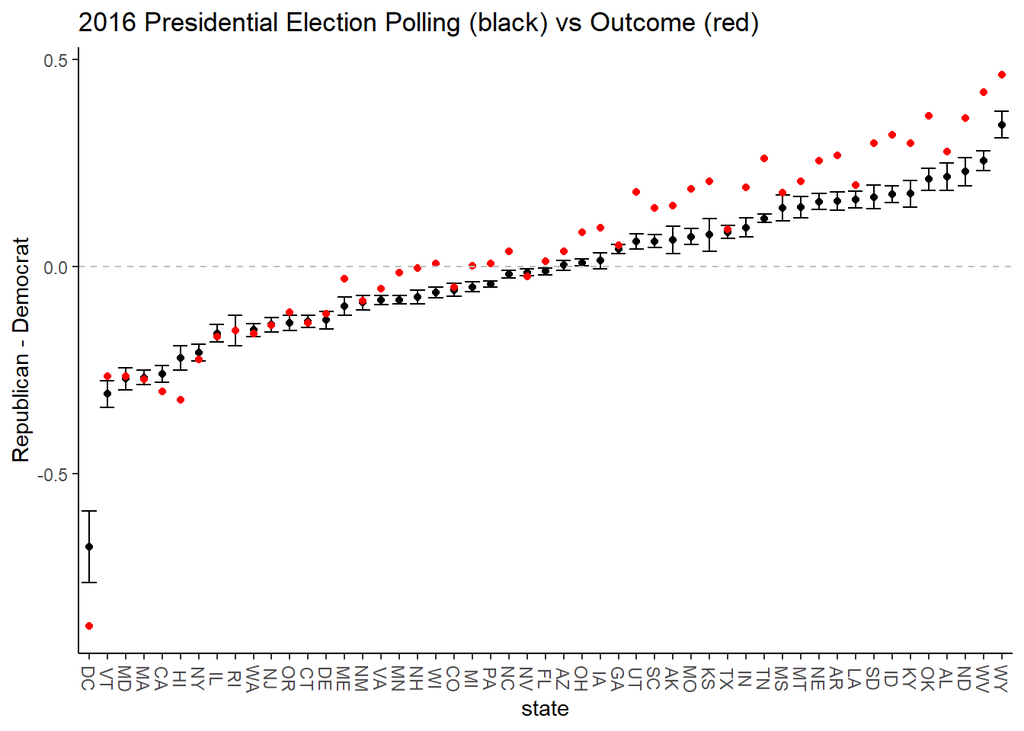

```r
# hint use the code below
reduced_polls %>%
  filter( type=="Pres", year %in% 2016 ) %>%
  mutate( state=reorder(state, spread.mean, mean) ) %>%

  ggplot(aes(state, spread.mean) ) + geom_point() +

  geom_errorbar(aes(ymin=lower_CI, ymax=higher_CI), colour="black", width=.8) +
  geom_point( aes( state, spread_act.mean ), col="red" ) +
  theme_classic() +
  theme(axis.text.x=element_text(angle=-90, vjust=0.5)) +
  ylab("Republican - Democrat") +
  ggtitle("2016 Presidential Election Polling (black) vs Outcome (red)") +
  geom_hline(yintercept=0, linetype="dashed", color="grey")
```

It is clear that most state-level results fall outside the 95% confidence interval, and in the Republican direction.

## Part 7 (10 pts)

Which states did Donald Trump win in the 2016 presidential election, despite the entire 95% confidence intervals being in favor of his opponent, Hillary Clinton?

**Solution**:

```r
reduced_polls %>%
  filter(year == 2016, type == "Pres", lower_CI < 0 & higher_CI < 0, spread_act.mean > 0)
```

| race_state | type | year | state | spread.mean | spread.stdev | spread_act.mean | num_polls | lower_CI | higher_CI | confidence_interval |
| --- | --- | --- | --- | --- | --- | --- | --- | --- | --- | --- |
| 2016_Pres_FL | Pres | 2016 | FL | -0.01199753 | 0.03634922 | 0.012 | 81 | -0.01991358 | -0.004081479 | 1 |
| 2016_Pres_MI | Pres | 2016 | MI | -0.04893061 | 0.03946578 | 0.002 | 49 | -0.05998103 | -0.037880193 | 1 |
| 2016_Pres_NC | Pres | 2016 | NC | -0.01833768 | 0.03718726 | 0.036 | 69 | -0.02711225 | -0.009563115 | 1 |
| 2016_Pres_PA | Pres | 2016 | PA | -0.04319296 | 0.03136429 | 0.007 | 71 | -0.05048858 | -0.035897335 | 1 |
| 2016_Pres_WI | Pres | 2016 | WI | -0.06266222 | 0.04201595 | 0.007 | 45 | -0.07493842 | -0.050386021 | 1 |

Donald Trump won Florida, Michigan, North Carolina, Pennsylvania, and Wisconsin, despite the entire 95% confidence intervals from polling data predicting a win for Hillary Clinton.

## Part 8 (10 pts)

Looking again at all races, calculate the the difference between $\theta$ and $\hat{\theta}$ (Hint: use the data for all races in the `reduced_polls` object created in Part 4). We call this the bias term. Add these values as a column to `reduced_polls`.

**Solution**:

```r
reduced_polls$bias_term <- reduced_polls$spread_act.mean - reduced_polls$spread.mean
```

## Part 9 (10 pts)

Plot and compare the distribution of bias terms for races in each year. Describe the bias patterns. Are these centered around zero? Give possible explanations.

**Solution**:

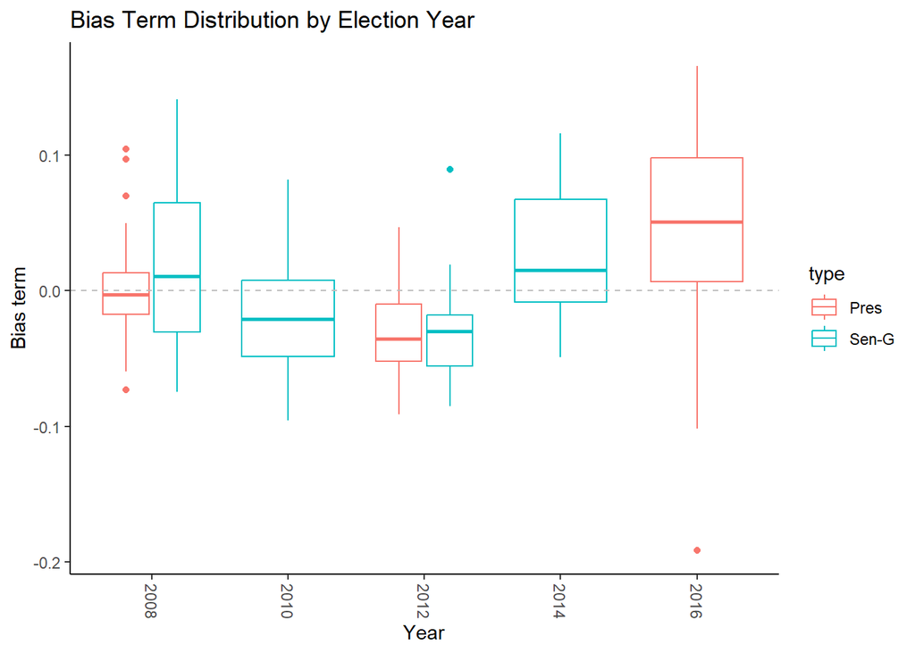

```r
reduced_polls %>%
  ggplot(aes(factor(year), bias_term, col=type) ) +
  theme_classic() +
  theme(axis.text.x=element_text(angle=-90, vjust=0.5)) +
  geom_boxplot()+
  xlab("Year") +
  ylab("Bias term") +
  ggtitle("Bias Term Distribution by Election Year") +
  geom_hline(yintercept=0, linetype="dashed", color="grey")
```

I used boxplots to visualize the data and compare the distribution of bias terms for races in each year. Most years do not have outliers, or only have one outlier, with the exception of 2008. The distributions are not exactly centered around 0. Since the bias term is calculated using spread means using Republican votes - Democrat votes, elections centered below 0 favor Democrats, while elections centered above 0 favor Republicans. Aside from the Senate election in 2008, most of the elections from 2008 - 2012 were biased towards Democrats, while the elections from 2014 - 2016 were biased towards Republicans.

## Conclusion

The results of this analysis aim to provide insights into the nature and extent of biases present in election polls. These findings serve to shed light on the factors influencing poll accuracy and contribute to discussions on improving polling methodologies.